# Forecasting Paediatric Emergency Department Attendances

HPDM097 – Making a Difference with Health Data

## Executive Summary

This project was undertaken to support an NHS trust forecast daily paediatric emergency department attendances over a 28-day horizon, with the aim of informing staffing decisions.

Historical daily attendance data were analysed for underlying patterns. The series showed strong weekly seasonality, with higher attendances on certain days of the week, as well as seasonal effects over the year. Day-to-day variability was high, but there was no evidence of a sustained long-term trend over the study period.

Forecasting approaches were evaluated using a rolling-origin cross-validation framework. Simple naïve methods were first assessed to establish a baseline. These were then compared with two more advanced approaches. SARIMAX models demand as a stochastic time series, explicitly capturing autocorrelation and seasonal structure through autoregressive and moving-average components. Prophet is an additive regression model that represents demand as the sum of trend, seasonality, and changepoint effects. Forecast accuracy was assessed using standard error metrics across the full 28-day forecast horizon.

Prophet consistently outperformed both the naïve benchmarks and the SARIMAX model. On this basis, Prophet was selected for final forecasting.

A 28-day forecast with prediction intervals was produced to support staffing decisions over the next four weeks. All analyses were implemented in reproducible Python code, enabling the forecasting framework to be updated as new data become available.

A chart showing the 28 day forecast is included near the bottom of this notebook.

## 1.1 Introduction

Demand forecasting can help to support service delivery. Short-term forecasts help hospitals plan staffing levels and manage operational pressures. Paediatric emergency attendances are influenced by factors which can make demand variable and difficult to forecast accurately.

The aim of this project is to develop and evaluate a short-term forecasting approach for daily paediatric ED attendances. Using historical attendance data, the task is to identify a suitable forecasting method and generate a 28-day forecast to support staffing decisions within an NHS acute trust.

## 1.2 Objectives

The objectives of this project are to:

- Explore and describe patterns in daily paediatric emergency department attendances
- Evaluate naïve and statistical forecasting methods for short-term demand
- Select a forecasting approach suitable for supporting staffing decisions
- Produce a reproducible 28-day forecast of paediatric ED attendances

## 2 Setup

This analysis was conducted in Python using the HDS_forecast environment provided for the module. All results are fully reproducible by running the notebook from top to bottom. Scientific computing and time-series libraries were used for data handling, modelling, and visualisation. The input data file path is defined in the cell below.

```python
# ------------------------------------------------------------
# 2. Import libraries and data path
# ------------------------------------------------------------

import pandas as pd
import numpy as np
import matplotlib.pyplot as plt
import statsmodels.api as sm
import warnings
import logging
from IPython.display import display
from prophet import Prophet
from pmdarima import auto_arima
from prophet import Prophet
from statsmodels.tsa.statespace.sarimax import SARIMAX
from statsmodels.tools.sm_exceptions import ConvergenceWarning

# Path to data file
DATA_FILE = "paediatrics_train.csv"

# Silence warnings and logs to keep the notebook clean
warnings.filterwarnings("ignore", category=ConvergenceWarning)
logging.getLogger("cmdstanpy").setLevel(logging.ERROR)
```

## 3. Data Description and Initial Analysis

The dataset consists of counts of paediatric emergency department attendances between the April 2014 and February 2017. Observations are recorded at daily frequency.

```python
# ------------------------------------------------------------
# 3.1 Load and inspect data
# ------------------------------------------------------------

df = pd.read_csv(DATA_FILE, parse_dates=["date"], index_col="date")
df = df.asfreq("D")

print(df.head(), "\n")
print(df.info())
```

```
            paed_ed_attends
date
2014-04-01               47
2014-04-02               46
2014-04-03               47
2014-04-04               48
2014-04-05               52

<class 'pandas.core.frame.DataFrame'>
DatetimeIndex: 1056 entries, 2014-04-01 to 2017-02-19
Freq: D
Data columns (total 1 columns):
 #   Column           Non-Null Count  Dtype
---  ------           --------------  -----
 0   paed_ed_attends  1056 non-null   int64
dtypes: int64(1)
memory usage: 16.5 KB
None
```

### 3.2 Data Quality Checks

The data was checked for missing values, duplicate or missing dates, negative or non integer counts. None were identified.

```python
# ------------------------------------------------------------
# 3.2 Data Quality Checks
# ------------------------------------------------------------

# Missing values
missing_values = df.isna().sum()

# Duplicate dates
duplicate_dates = df.index.duplicated().sum()

# Check for continuous daily frequency
full_date_range = pd.date_range(
    start=df.index.min(), end=df.index.max(), freq="D"
)
missing_dates = full_date_range.difference(df.index)

# Validity of attendance counts
negative_counts = (df["paed_ed_attends"] < 0).sum()
non_integer_counts = (df["paed_ed_attends"] % 1 != 0).sum()

# Display results
print("Missing values per column:")
print(missing_values, "\n")

print(f"Number of duplicate dates: {duplicate_dates}")
print(f"Number of missing dates in daily sequence: {len(missing_dates)}")
print(f"Negative attendance values: {negative_counts}")
print(f"Non-integer attendance values: {non_integer_counts}")
```

```
Missing values per column:
paed_ed_attends    0
dtype: int64

Number of duplicate dates: 0
Number of missing dates in daily sequence: 0
Negative attendance values: 0
Non-integer attendance values: 0
```

### 3.3 Train Test Split

The final 28 days of the available time series were reserved as a hold-out test set. This test set represents the future period for which staffing decisions would need to be made in practice.

The test data were not used during exploratory analysis, model fitting, or model selection. All model development and comparison were carried out using the remaining historical data (the training set), ensuring that forecast performance is evaluated on genuinely unseen observations.

```python
# ------------------------------------------------------------
# 3.3 Train-Test split
# ------------------------------------------------------------

HORIZON = 28

ts_full = df["paed_ed_attends"].astype(float)
ts_train = ts_full.iloc[:-HORIZON]
ts_test  = ts_full.iloc[-HORIZON:]

# Print summary
print(f"Total observations: {len(ts_full)}")
print(f"Training observations: {len(ts_train)}")
print(f"Test observations: {len(ts_test)}")

print("\nTraining period:")
print(f"  {ts_train.index.min().date()} to {ts_train.index.max().date()}")

print("\nTest period (held out):")
print(f"  {ts_test.index.min().date()} to {ts_test.index.max().date()}")
```

```
Total observations: 1056
Training observations: 1028
Test observations: 28

Training period:
  2014-04-01 to 2017-01-22

Test period (held out):
  2017-01-23 to 2017-02-19
```

### 3.4 Overview of Time Series Behaviour

Attendances show day-to-day variability with no strong long-term trend, but with periodic peaks which may suggest winter respiratory illnesses.

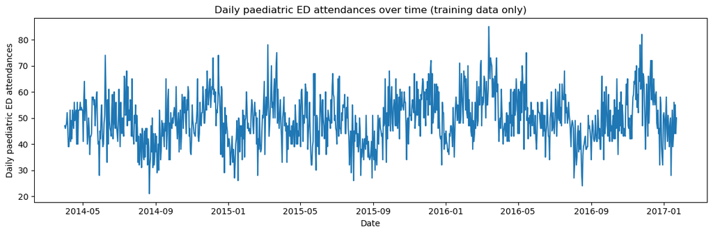

```python
# ------------------------------------------------------------
# 3.4 Visualise the data
# ------------------------------------------------------------

# Line plot of training data only
plt.figure(figsize=(12, 4))
plt.plot(ts_train.index, ts_train.values)
plt.xlabel("Date")
plt.ylabel("Daily paediatric ED attendances")
plt.title("Daily paediatric ED attendances over time (training data only)")
plt.tight_layout()
plt.show()
```

##### 3.5 Seasonal effects

To explore longer-term seasonal effects, mean daily attendances per month were aggregated across years. Attendances show day-to-day variability with no strong long-term trend. Peaks in November and March suggest seasonal effects consistent with winter respiratory illness.

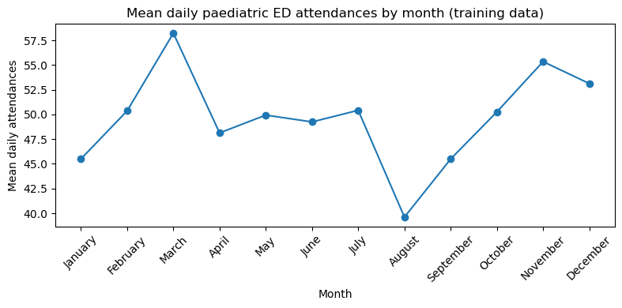

```python
# ------------------------------------------------------------
# 3.5.1 Visualise seasonality by calendar month
# ------------------------------------------------------------

# Convert series to DataFrame for feature engineering
train_month = ts_train.to_frame(name="paed_ed_attends")

# Add month information
train_month["month"] = train_month.index.month
train_month["month_name"] = train_month.index.month_name()

# Calculate mean daily attendances per calendar month
monthly_mean = (
    train_month
    .groupby(["month", "month_name"])["paed_ed_attends"]
    .mean()
    .reset_index()
    .sort_values("month")
)

# Plot mean daily attendances by month
plt.figure(figsize=(8, 4))
plt.plot(
    monthly_mean["month_name"],
    monthly_mean["paed_ed_attends"],
    marker="o"
)
plt.xlabel("Month")
plt.ylabel("Mean daily attendances")
plt.title("Mean daily paediatric ED attendances by month (training data)")
plt.xticks(rotation=45)
plt.tight_layout()
plt.show()
```

### 3.5.2 Short term effects

To examine variation within-week, attendances were grouped by day of week and summarised using a boxplot. A weekly pattern is suggested, with higher attendances on Sundays and Mondays.

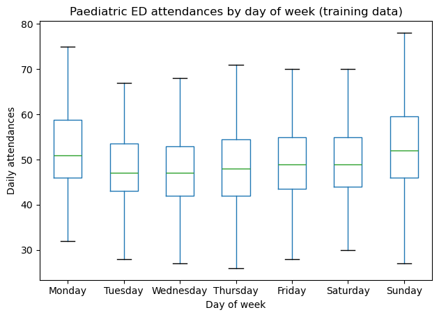

```python
# ------------------------------------------------------------
# 3.5.2 Visualise seasonality by day of week
# ------------------------------------------------------------

# Convert series to DataFrame
train_dayofweek = ts_train.to_frame(name="paed_ed_attends")

# Add day-of-week
train_dayofweek["day_name"] = train_dayofweek.index.day_name()

# Order for days of the week
weekday_order = [
    "Monday",
    "Tuesday",
    "Wednesday",
    "Thursday",
    "Friday",
    "Saturday",
    "Sunday",
]

train_dayofweek["day_name"] = pd.Categorical(
    train_dayofweek["day_name"],
    categories=weekday_order,
    ordered=True
)

# Boxplot by day of week
plt.figure(figsize=(8, 4))
train_dayofweek.boxplot(
    column="paed_ed_attends",
    by="day_name",
    grid=False,
    showfliers=False
)
plt.suptitle("")
plt.title("Paediatric ED attendances by day of week (training data)")
plt.xlabel("Day of week")
plt.ylabel("Daily attendances")
plt.tight_layout()
plt.show()
```

### 3.6 Distribution and variability

The distribution of daily attendances was examined. Observations cluster around a central range. There are occasional higher-demand days. There are no extreme outliers. Inspection of rolling statistics suggests variability is broadly stable over time.

These characteristics support the use of absolute-error-based evaluation metrics such as mean absolute error (MAE)

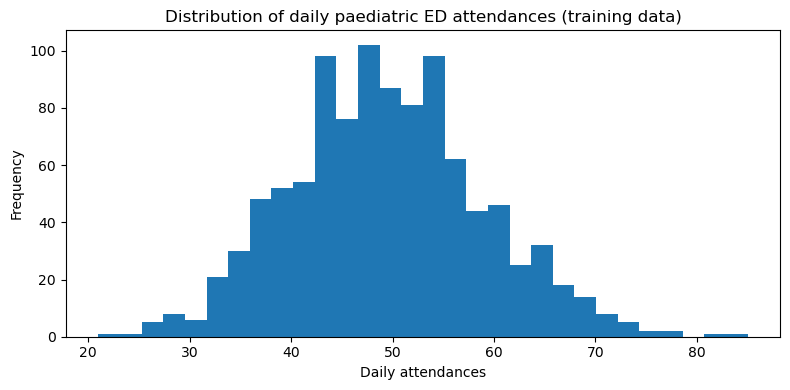

```python
# ------------------------------------------------------------
# 3.6.1 Visualise distribution of daily attendances
# ------------------------------------------------------------

# Histogram of daily attendances (distribution)
plt.figure(figsize=(8, 4))
plt.hist(ts_train, bins=30)
plt.xlabel("Daily attendances")
plt.ylabel("Frequency")
plt.title("Distribution of daily paediatric ED attendances (training data)")
plt.tight_layout()
plt.show()
```

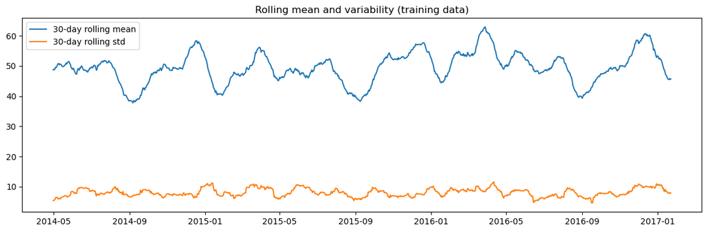

```python
# ------------------------------------------------------------
# 3.6.2 Visualise rolling mean and variability
# ------------------------------------------------------------

# Rolling mean and variability of daily attendances (line plot)
rolling_mean = ts_train.rolling(30).mean()
rolling_std = ts_train.rolling(30).std()

plt.figure(figsize=(12, 4))
plt.plot(rolling_mean, label="30-day rolling mean")
plt.plot(rolling_std, label="30-day rolling std")
plt.legend()
plt.title("Rolling mean and variability (training data)")
plt.tight_layout()
plt.show()
```

### 3.7 Implications for Forecasting

In summary, daily paediatric emergency department attendances show clear seasonal patterns. Winter months tend to be busier than summer months, and across the week attendances are highest on Sundays and Mondays. Day-to-day attendance numbers vary considerably, but this variability appears broadly stable over time. There is no clear evidence of a sustained long-term increase or decrease in attendances over the study period. Taken together, these findings suggest a forecasting approach which make uses of recently and seasonally similar days.

## 4. Forecasting Framework

This section outlines approach used to evaluate forecasting models.

### 4.1 Forecasting Task Definition

The forecasting task is to predict daily paediatric emergency department attendances over a 28-day horizon. This horizon reflects the Trust’s operational need to plan staffing levels several weeks in advance, balancing rota preparation with the inherent uncertainty of emergency care demand.

The primary objective of the forecasting exercise is therefore short-term accuracy, rather than long-term trend estimation. Forecasts are required at a daily resolution, and performance is assessed in terms of how closely predicted attendances match observed values over the forecast horizon.

### 4.2 Error Metrics

Forecast accuracy was evaluated using standard error metrics. Mean Absolute Error (MAE) measures the average magnitude of forecast errors and is easy to interpret in the original units of the data. Root Mean Squared Error (RMSE) penalises larger errors more heavily.

```python
# ------------------------------------------------------------
# 4.2 Error metric functions
# ------------------------------------------------------------

def mae(y_true, y_pred):
    """
    Compute Mean Absolute Error (MAE).

    MAE measures the average absolute difference between observed
    and predicted values, expressed in the original units of the data.
    """
    return float(np.mean(np.abs(y_true - y_pred)))


def rmse(y_true, y_pred):
    """
    Compute Root Mean Squared Error (RMSE).

    RMSE penalises larger errors more heavily than MAE and is sensitive
    to occasional large forecast deviations.
    """
    return float(np.sqrt(np.mean((y_true - y_pred) ** 2)))


def smape(y_true, y_pred):
    """
    Compute Symmetric Mean Absolute Percentage Error (sMAPE).

    sMAPE provides a scale-free measure of forecast accuracy by expressing
    errors as a percentage of the average magnitude of observed and
    predicted values.
    """
    denom = (np.abs(y_true) + np.abs(y_pred)) / 2.0
    denom = np.where(denom == 0, 1e-8, denom)
    return float(np.mean(np.abs(y_true - y_pred) / denom) * 100)
```

### 4.3 Cross-Validation Strategy

Model performance was assessed using rolling origin cross-validation with an expanding training window. Models are repeatedly trained on historical data and evaluated on subsequent 28-day forecast periods, mimicking the way forecasts would be generated in routine operational use.

At each step, errors were measured over the entire forecast window, making it possible to assess both overall accuracy and how performance changes as the forecast horizon increases.

```python
# ------------------------------------------------------------
# 4.3 Cross-Validation
# ------------------------------------------------------------

INITIAL_WINDOW = 365 * 2
STEP = 7

def rolling_origin_cv(series, horizon=28, initial_window=365*2, step=1, forecaster=None, long_format=True):
    """
    Perform rolling-origin cross-validation with an expanding training window.

    At each forecast origin, the model is trained on all observations up to the
    origin and used to generate a multi-step forecast of length `horizon`.
    The forecast origin is then advanced by `step` observations and the
    process is repeated.

    Parameters
    ----------
    series : pd.Series
        Univariate time series indexed by date.
    horizon : int, default=28
        Number of future time steps to forecast at each origin.
    initial_window : int, default=365*2
        Number of observations used in the initial training window.
    step : int, default=1
        Number of observations by which the forecast origin is advanced
        between successive folds.
    forecaster : callable
        Function of the form forecaster(train_series, horizon) that returns
        a forecast array of length `horizon`.
    long_format : bool, default=True
        If True, returns horizon-wise errors for each forecast origin.
        If False, returns aggregate error metrics (MAE, RMSE, sMAPE) per origin.

    Returns
    -------
    pd.DataFrame
        Cross-validation results. In long format, one row per origin and
        forecast horizon step is returned. In short format, one row per
        forecast origin containing aggregate error metrics is returned.
    """
    if forecaster is None:
        raise ValueError("Pass forecaster(train_series, horizon) -> forecast array")

    series = series.dropna()
    n = len(series)

    if initial_window + horizon > n:
        raise ValueError("initial_window + horizon > series length")

    results = []
    last_origin_start = n - horizon

    for origin_end in range(initial_window, last_origin_start + 1, step):
        train_series = series.iloc[:origin_end]
        test_slice = series.iloc[origin_end: origin_end + horizon]

        y_pred = np.asarray(forecaster(train_series, horizon), dtype=float)
        y_true = test_slice.values.astype(float)

        origin_date = test_slice.index[0]

        if long_format:
            abs_err = np.abs(y_true - y_pred)
            for h in range(1, horizon + 1):
                results.append({
                    "origin_date": origin_date,
                    "h": h,
                    "y_true": y_true[h-1],
                    "y_pred": y_pred[h-1],
                    "abs_error": abs_err[h-1],
                })
        else:
            results.append({
                "origin_date": origin_date,
                "MAE": mae(y_true, y_pred),
                "RMSE": rmse(y_true, y_pred),
                "sMAPE": smape(y_true, y_pred),
            })

    return pd.DataFrame(results)
```

## 5. Benchmark Models (Naïve Methods)

### 5.1 Rationale for Benchmark Models

In time series forecasting, naïve methods often perform well, particularly when strong seasonal patterns are present. These methods provide a useful reference point for evaluating whether more complex models offer meaningful improvement.

### 5.2 Benchmark Model Definitions

#### Naïve (Last Observation) Forecast

The naïve forecast assumes that future attendances will be equal to the most recently observed value.

#### Seasonal Naïve (Weekly) Forecast

The seasonal naïve forecast accounts for the observed weekly pattern in attendances. Forecasts are generated by repeating the values observed in the most recent week, so that, for example, a future Monday is forecast using the most recent Monday’s attendance.

### 5.3 Benchmark Model Implementation

This code defines the naïve and seasonal naïve forecasting functions, which take historical attendance data as input and return a 28-day forecast.

```python
# ------------------------------------------------------------
# 5.3 Benchmark forecasters
# ------------------------------------------------------------

def forecast_naive1(train_series: pd.Series, horizon: int) -> np.ndarray:
    """
    Naive benchmark forecaster (NF1).

    Forecasts all future time steps as the last observed value in the
    training series.
    """
    last_val = float(train_series.iloc[-1])
    return np.repeat(last_val, horizon)


def forecast_snaive_weekly(
    train_series: pd.Series, horizon: int
) -> np.ndarray:
    """
    Seasonal naive benchmark forecaster (weekly).

    Forecasts future values by repeating the most recent observed
    weekly pattern (last 7 days).
    """
    season_length = 7
    last_week = train_series.iloc[-season_length:].to_numpy(dtype=float)
    reps = int(np.ceil(horizon / season_length))
    return np.tile(last_week, reps)[:horizon]
```

### 5.4 Benchmark Model Evaluation

```python
# ------------------------------------------------------------
# 5.4.1 Benchmark Model Evaluation (Rolling origin CV on training data)
# ------------------------------------------------------------
y_train = ts_train

cv_naive1 = rolling_origin_cv(
    series = y_train,
    forecaster=forecast_naive1,
    long_format = True,
)

cv_snaive = rolling_origin_cv(
    series=y_train,
    forecaster=forecast_snaive_weekly,
    long_format = True,
)

# Overall MAE across all origins and horizons
summary = pd.DataFrame(
    {
        "Model": ["Naive1 (last value)", "Seasonal Naive (weekly)"],
        "Mean MAE (h=1..28)": [
            cv_naive1["abs_error"].mean(),
            cv_snaive["abs_error"].mean(),
        ],
    }
).sort_values("Mean MAE (h=1..28)")

display(summary)
```

|  | Model | Mean MAE (h=1..28) |
| --- | --- | --- |
| 0 | Naive1 (last value) | 9.308777 |
| 1 | Seasonal Naive (weekly) | 9.329863 |

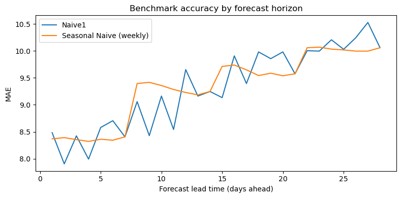

```python
# ------------------------------------------------------------
# 5.4.2 visualise horizon-wise accuracy
# ------------------------------------------------------------

# Horizon-wise MAE
mae_by_h_naive1 = (
    cv_naive1.groupby("h")["abs_error"].mean().reset_index(name="MAE")
)
mae_by_h_snaive = (
    cv_snaive.groupby("h")["abs_error"].mean().reset_index(name="MAE")
)

# Plot horizon-wise MAE
plt.figure(figsize=(8, 4))
plt.plot(mae_by_h_naive1["h"], mae_by_h_naive1["MAE"], label="Naive1")
plt.plot(
    mae_by_h_snaive["h"],
    mae_by_h_snaive["MAE"],
    label="Seasonal Naive (weekly)",
)
plt.xlabel("Forecast lead time (days ahead)")
plt.ylabel("MAE")
plt.title("Benchmark accuracy by forecast horizon")
plt.legend()
plt.tight_layout()
plt.show()
```

## 6. Candidate Forecasting Model

### 6.1 Choice of model

Three advanced forecasting approaches were initially considered. SARIMAX models temporal dependence and seasonality within a statistical time-series framework. Prophet is an additive regression model designed for operational forecasting, combining trend, seasonality, and changepoint detection. A neural network model was also explored, using lagged observations and calendar features to capture non-linear patterns.

The neural network was excluded after preliminary evaluation, as it showed poor and unstable out-of-sample performance- probably due to error accumulation in recursive multi-step forecasting. The analysis therefore focused on SARIMAX and Prophet.

## 6.2 SARIMAX

### 6.2.1 SARIMAX order selection

auto_arima was used to select appropriate SARIMAX model orders from the training data

The automated model selection identified a SARIMAX(1,1,2) model with a weekly seasonal moving-average component of order (0,0,2)\₇, capturing short-term dependence and weekly seasonality in the data.

```python
# ------------------------------------------------------------
# 6.2.1 SARIMAX Order Selection Using auto-ARIMA
# ------------------------------------------------------------

y = ts_train.astype(float)

y0 = y.iloc[:INITIAL_WINDOW]

auto_model = auto_arima(
    y0,
    seasonal=True,
    m=7,
    stepwise=True,
    suppress_warnings=True,
    error_action="ignore",
)

ORDER = auto_model.order
SEASONAL_ORDER = auto_model.seasonal_order

print("Selected order:", ORDER)
print("Selected seasonal_order:", SEASONAL_ORDER)
```

```
Selected order: (1, 1, 2)
Selected seasonal_order: (0, 0, 2, 7)
```

### 6.2.2 SARIMAX forecasting function

This function refits a SARIMAX model with fixed, pre-selected orders to the available training data and produces a multi-step forecast for use in rolling-origin cross-validation.

```python
# ------------------------------------------------------------
# 6.2.2 SARIMAX forecasting function
# ------------------------------------------------------------

def forecast_sarimax(
    train_series: pd.Series,
    horizon: int,
    order=ORDER,
    seasonal_order=SEASONAL_ORDER
) -> np.ndarray:
    """
    Fit a SARIMAX model to the training series and produce a multi-step forecast.

    The model is refitted at each call using the supplied training data and
    pre-selected ARIMA and seasonal orders. This function is intended for use
    within a rolling-origin cross-validation framework, where the training
    window expands over time.

    Parameters
    ----------
    train_series : pd.Series
        Univariate time series of daily paediatric ED attendances, indexed by date.
    horizon : int
        Number of days ahead to forecast.
    order : tuple
        Non-seasonal ARIMA order (p, d, q).
    seasonal_order : tuple
        Seasonal ARIMA order (P, D, Q, m), where m is the seasonal period.

    Returns
    -------
    np.ndarray
        Array of length `horizon` containing the point forecasts.
    """
    model = SARIMAX(
        train_series.astype(float),
        order=order,
        seasonal_order=seasonal_order,
        enforce_stationarity=False,
        enforce_invertibility=False,
    )
    fit = model.fit(disp=False)
    preds = fit.forecast(steps=horizon)
    return preds.to_numpy(dtype=float)
```

### 6.3 Prophet

These functions format the data for Prophet, refit an additive forecasting model with weekly and yearly seasonality, and generate multi-step forecasts for use in rolling-origin cross-validation.

```python
# ------------------------------------------------------------
# 6.3 Prophet functions
# ------------------------------------------------------------

def to_prophet_df(y_series: pd.Series) -> pd.DataFrame:
    """
    Convert a time series into Prophet-compatible DataFrame format.

    Parameters
    ----------
    y_series : pd.Series
        Univariate time series indexed by date.

    Returns
    -------
    pd.DataFrame
        DataFrame with columns:
        - 'ds': datestamps
        - 'y' : observed values
    """
    df = pd.DataFrame({"ds": y_series.index, "y": y_series.values})
    return df


def fit_predict_prophet(y_train: pd.Series, horizon: int):
    """
    Fit a Prophet model to the training data and generate a multi-step forecast.

    The model includes weekly and yearly seasonality and is refitted each time
    the function is called. This design supports use within a rolling-origin
    cross-validation framework.

    Parameters
    ----------
    y_train : pd.Series
        Training time series of daily paediatric ED attendances.
    horizon : int
        Number of days ahead to forecast.

    Returns
    -------
    tuple
        - np.ndarray of length `horizon` containing point forecasts
        - fitted Prophet model object
    """
    df_train = to_prophet_df(y_train)

    model = Prophet(
        weekly_seasonality=True,
        yearly_seasonality=True,
        daily_seasonality=False
    )
    model.fit(df_train)

    future = model.make_future_dataframe(periods=horizon, freq="D")
    forecast = model.predict(future)

    preds = forecast["yhat"].iloc[-horizon:].to_numpy()
    return preds, model


def forecast_prophet(train_series: pd.Series, horizon: int) -> np.ndarray:
    """
    Wrapper function to produce Prophet forecasts for rolling-origin CV.

    Parameters
    ----------
    train_series : pd.Series
        Training time series indexed by date.
    horizon : int
        Number of days ahead to forecast.

    Returns
    -------
    np.ndarray
        Array of length `horizon` containing the point forecasts.
    """
    preds, _ = fit_predict_prophet(train_series, horizon)
    return preds
```

### 6.4 Model comparison

Each forecasting method is evaluated using the same rolling-origin cross-validation scheme on the training data. For every model, forecasts are generated at multiple forecast origins and summarised using MAE, RMSE, and sMAPE over the full 28-day horizon. Results from all models are then aggregated to compare average performance and variability on a common, out-of-sample basis.

```python
# ------------------------------------------------------------
# 6.4 Cross-Validated Model Comparison
# ------------------------------------------------------------

y = ts_train.astype(float)

cv_naive1 = rolling_origin_cv(y, forecaster=forecast_naive1, long_format = False)
cv_snaive = rolling_origin_cv(y, forecaster=forecast_snaive_weekly, long_format = False)
cv_sarimax = rolling_origin_cv(y, forecaster=forecast_sarimax, long_format = False)
cv_prophet = rolling_origin_cv(y, forecaster=forecast_prophet, long_format = False)

# add model labels
for df, name in [
    (cv_naive1, "Naive1"),
    (cv_snaive, "SNaive_weekly"),
    (cv_sarimax, "SARIMAX_auto"),
    (cv_prophet, "Prophet"),
]:
    df["model"] = name


cv_all = pd.concat([cv_naive1, cv_snaive, cv_sarimax, cv_prophet], ignore_index=True)

# Summaries across all origins AND all horizons (h=1..28)
summary = (cv_all
           .groupby("model")[["MAE", "RMSE", "sMAPE"]]
           .agg(["mean", "std"]))
summary
```

[output not shown]

[output cut: 487 more lines]

[output not shown]

| model | MAE mean | MAE std | RMSE mean | RMSE std | sMAPE mean | sMAPE std |
| --- | --- | --- | --- | --- | --- | --- |
| Naive1 | 9.308777 | 3.805231 | 11.121489 | 3.911863 | 18.655689 | 7.331535 |
| Prophet | 6.316963 | 1.268385 | 7.851565 | 1.445909 | 12.679395 | 2.021999 |
| SARIMAX_auto | 7.823697 | 2.416985 | 9.627867 | 2.703499 | 15.622140 | 4.658328 |
| SNaive_weekly | 9.329863 | 2.557154 | 11.596437 | 2.884205 | 18.594940 | 4.653329 |

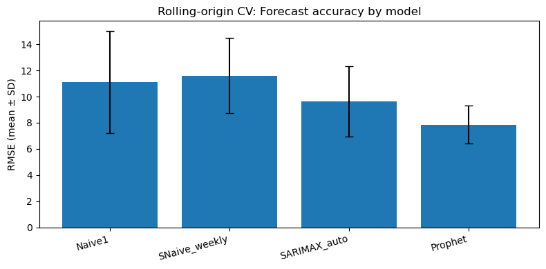

```python
# ------------------------------------------------------------
# 6.5 Model Comparison Chart
# ------------------------------------------------------------

# --- Summarise RMSE for chart (mean ± SD) ---
rmse_summary = (cv_all
                .groupby("model")["RMSE"]
                .agg(["mean", "std"])
                .reindex(["Naive1", "SNaive_weekly", "SARIMAX_auto", "Prophet"]))

# --- Plot: bar chart with error bars ---
plt.figure(figsize=(8, 4))
x = np.arange(len(rmse_summary.index))

plt.bar(x, rmse_summary["mean"].values, yerr=rmse_summary["std"].values, capsize=4)
plt.xticks(x, rmse_summary.index, rotation=15, ha="right")
plt.ylabel("RMSE (mean ± SD)")
plt.title("Rolling-origin CV: Forecast accuracy by model")
plt.tight_layout()
plt.show()
```

## 7. Model Selection and Final Forecast

### 7.1 Model Selection

The Prophet model demonstrated the strongest overall performance, achieving lower mean MAE and sMAPE than the naïve benchmarks and the SARIMAX model, with comparatively low variability across folds.

On this basis, Prophet was selected as the preferred model for the final forecasts.

### 7.2 Final 28 day Forecast

Overall demand is expected to rise over the forecast period, which may be relevant for staffing. Day-to-day variability remains substantial, reflecting the nature of childhood illness.

The shaded prediction interval illustrates the uncertainty surrounding the point forecast. While most days are expected to fall close to the central forecast, higher-demand days may occur. Demand is expected to fall in the grey shaded band 80% of the time.

```
19:14:24 - cmdstanpy - INFO - Chain [1] start processing
19:14:24 - cmdstanpy - INFO - Chain [1] done processing
```

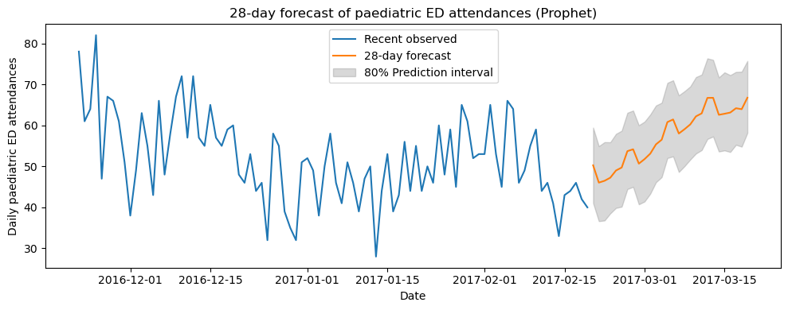

```python
# ------------------------------------------------------------
# 7.2 Final 28 day Forecast (prophet)
# ------------------------------------------------------------

y_full = ts_full.astype(float)

df_full = pd.DataFrame({
    "ds": pd.to_datetime(y_full.index),
    "y": y_full.values
})


final_model = Prophet(
    weekly_seasonality=True,
    yearly_seasonality=True,
    daily_seasonality=False
)

final_model.fit(df_full)

# -------------------------------
# Forecast next 28 days
# -------------------------------
H = 28

future = final_model.make_future_dataframe(periods=H, freq="D")
forecast = final_model.predict(future)

fcst_28 = forecast.tail(H).copy()

forecast_mean = forecast["yhat"].iloc[-H:]
forecast_ci_lower = forecast["yhat_lower"].iloc[-H:]
forecast_ci_upper = forecast["yhat_upper"].iloc[-H:]

# -------------------------------
# Plot recent observations + forecast
# -------------------------------
plt.figure(figsize=(10, 4))

plt.plot(
    y_full.index[-90:],
    y_full.iloc[-90:],
    label="Recent observed"
)

plt.plot(
    fcst_28["ds"],
    fcst_28["yhat"],
    label=f"{H}-day forecast"
)

plt.fill_between(
    fcst_28["ds"],
    fcst_28["yhat_lower"],
    fcst_28["yhat_upper"],
    color="grey",
    alpha=0.3,
    label="80% Prediction interval"
)

plt.xlabel("Date")
plt.ylabel("Daily paediatric ED attendances")
plt.title(f"{H}-day forecast of paediatric ED attendances (Prophet)")
plt.legend()
plt.tight_layout()
plt.show()
```

## 8. Conclusion

This project evaluated methods for forecasting daily paediatric emergency department attendances to support short-term staffing decisions. Using rolling-origin cross-validation, the Prophet model outperformed naïve benchmarks and a SARIMAX specification.

The 28-day forecast above has been produced to inform staffing over the next four weeks, with prediction intervals used to reflect uncertainty in daily demand.

The analysis was implemented in reproducible Python code, enabling regular updates as new data become available.